# Phlox Project - Geralin, Natascha, Jala

**Installing Libraries if Necessary (for non-frequent R users)

```r
if (!require("tidyverse")) install.packages('tidyverse')
if (!require("RColorBrewer")) install.packages('RColorBrewer')
if (!require("paletteer")) install.packages('paletteer')
if (!require("janitor")) install.packages('janitor')
if (!require("here")) install.packages('here')
```

```
## here() starts at /Users/natascha/Desktop/BIS15W2021_Group4_Project
```

```r
if (!require("naniar")) install.packages('naniar')
if (!require("stringr")) install.packages('stringr')
if (!require("shiny")) install.packages('shiny')
if (!require("shinydashboard")) install.packages('shinydashboard')
```

#Library

```r
library(tidyverse)
library(RColorBrewer)
library(paletteer)
library(janitor)
library(here)
library(naniar)
library(stringr)
library(shiny)
library(shinydashboard)
```

#Loading Original Data Sets and Cleaning Names The following data sets examine the pollinators, colors, and sizes associated with different species of flowers within the phlox family. Source: Landis, Jacob B. et al. (2018), Evolution of floral traits and impact of reproductive mode on diversification in the phlox family (Polemoniaceae), Molecular Phylogenetics and Evolution, Article-journal, https://doi.org/10.1016/j.ympev.2018.06.035 [Data:](https://datadryad.org/stash/dataset/doi:10.5061/dryad.2710pk5)

```r
flower_sizes_original <- read_csv(here("Plant+Pollinators Data", "Flower size measurements.csv")) %>%
  janitor::clean_names()
colors_and_pollinators_original <- read_csv(here("Plant+Pollinators Data", "Pollinator and flower color.csv")) %>%
  janitor::clean_names()
```

#Flower Sizes Data With the first data set, we’ll observe the lengths and widths of each species’ corollas, removing any NAs recorded for these variables.

```r
flower_sizes <- flower_sizes_original %>%
  select(herbarium_accession_sheet, species, flower_number, corolla_length_cm, corolla_width_throat_cm) %>%
  filter(corolla_length_cm != "NA", corolla_width_throat_cm != "NA")
flower_sizes
```

```
# A tibble: 3,006 x 5
   herbarium_accessio… species   flower_number corolla_length_… corolla_width_t…
   <chr>               <chr>             <dbl>            <dbl>            <dbl>
 1 Acanthogilia glori… Acanthog…             1             3.55            0.393
 2 Acanthogilia glori… Acanthog…             1             3.70            0.455
 3 Acanthogilia glori… Acanthog…             2             2.66            0.37
 4 Acanthogilia glori… Acanthog…             3             2.87            0.375
 5 Aliciella caespito… Aliciell…             1             1.65            0.241
 6 Aliciella caespito… Aliciell…             2             1.66            0.148
 7 Aliciella caespito… Aliciell…             3             1.88            0.201
 8 Aliciella formosa … Aliciell…             1             1.97            0.201
 9 Aliciella formosa … Aliciell…             2             2.12            0.286
10 Aliciella formosa … Aliciell…             3             2.05            0.23
# … with 2,996 more rows
```

##Checking classes of variables, making changes as necessary

```r
glimpse(flower_sizes)
```

```
Rows: 3,006
Columns: 5
$ herbarium_accession_sheet <chr> "Acanthogilia gloriosa KANU00172801", "Acant…
$ species                   <chr> "Acanthogilia gloriosa", "Acanthogilia glori…
$ flower_number             <dbl> 1, 1, 2, 3, 1, 2, 3, 1, 2, 3, 1, 2, 3, 1, 2,…
$ corolla_length_cm         <dbl> 3.552, 3.696, 2.660, 2.874, 1.652, 1.664, 1.…
$ corolla_width_throat_cm   <dbl> 0.393, 0.455, 0.370, 0.375, 0.241, 0.148, 0.…
```

Changing `species` from character to factor:

```r
flower_sizes$species <- as.factor(flower_sizes$species)
is.factor(flower_sizes$species)
```

```
## [1] TRUE
```

```r
flower_sizes %>%
  miss_var_summary() #To confirm that we have removed all NAs represented as "NA" from the size columns, as well as to get a count of any other NAs in the remaining columns
```

```
# A tibble: 5 x 3
  variable                  n_miss pct_miss
  <chr>                      <int>    <dbl>
1 herbarium_accession_sheet      0        0
2 species                        0        0
3 flower_number                  0        0
4 corolla_length_cm              0        0
5 corolla_width_throat_cm        0        0
```

#Calculate the means, standard deviations and length to width ratios of the corollas of each species:

```r
flower_sizes_calculated <- flower_sizes %>%
  group_by(species) %>%
  summarise(mean_corolla_length_cm = mean(corolla_length_cm, na.rm = TRUE),
         std_dev_corolla_length = sd(corolla_length_cm, na.rm = TRUE),
         mean_corolla_width_throat_cm = mean(corolla_width_throat_cm, na.rm = TRUE),
         std_dev_corolla_width_throat = sd(corolla_width_throat_cm, na.rm = TRUE),
         mean_length_width_ratio = mean_corolla_length_cm/mean_corolla_width_throat_cm)
flower_sizes_calculated #summary of sizes for each species, with means, standard deviations, and ratios calculated
```

```
# A tibble: 396 x 6
   species  mean_corolla_len… std_dev_corolla… mean_corolla_wi… std_dev_corolla…
 * <fct>                <dbl>            <dbl>            <dbl>            <dbl>
 1 Acantho…             3.20            0.506            0.398            0.0391
 2 Aliciel…             1.73            0.131            0.197            0.0467
 3 Aliciel…             2.12            0.0894           0.297            0.0645
 4 Aliciel…             1.58            0.408            0.209            0.0706
 5 Aliciel…             1.11            0.295            0.145            0.0258
 6 Aliciel…             0.818           0.129            0.158            0.0640
 7 Aliciel…             0.556           0.0207           0.0963           0.0205
 8 Aliciel…             0.518           0.110            0.0963           0.0220
 9 Aliciel…             0.636           0.0187           0.128            0.0255
10 Aliciel…             0.665           0.0471           0.141            0.0122
# … with 386 more rows, and 1 more variable: mean_length_width_ratio <dbl>
```

```r
n_distinct(flower_sizes_calculated$species)
```

```
[1] 396
```

There are 396 species in our flower sizes data sheet. Object `flower_sizes_calculated` should be used for the merge.

#Pollinator and Color Data With our second data set, we’ll observe the different colors and pollinators associated with each species. Note: this data is not yet clean.

```r
colors_and_pollinators <- colors_and_pollinators_original %>%
  rename(color_source="source", pollinator_source="source_1") %>%
  filter(pollinator != "NA")
colors_and_pollinators
```

```
# A tibble: 192 x 5
   species         color    color_source    pollinator         pollinator_source
   <chr>           <chr>    <chr>           <chr>              <chr>
 1 Acanthogilia g… white    Hsu and Hall 2… hummingbird        Hsu and Hall 2003
 2 Aliciella caes… red      Porter 1998     hummingbird        Grant and Grant …
 3 Aliciella hutc… white    Porter 1998     autogamous         Grant and Grant …
 4 Aliciella lept… white    Porter 1998     autogamous         Grant and Grant …
 5 Aliciella micr… white    Porter 1998     autogamous         Grant and Grant …
 6 Aliciella pinn… blue     Porter 1998     bee                Grant and Grant …
 7 Aliciella subn… red      Porter 1998     hummingbird        Grant and Grant …
 8 Allophyllum di… pink     Jepson Online   beefly             Grant and Grant …
 9 Allophyllum gi… blue-pu… Jepson Online   autogamous         Grant and Grant …
10 Allophyllum gl… blue-pu… Jepson Online   bee primary, seco… Grant and Grant …
# … with 182 more rows
```

##Checking classes of variables, making changes as necessary

```r
glimpse(colors_and_pollinators)
```

```
Rows: 192
Columns: 5
$ species           <chr> "Acanthogilia gloriosa", "Aliciella caespitosa", "Al…
$ color             <chr> "white", "red", "white", "white", "white", "blue", "…
$ color_source      <chr> "Hsu and Hall 2003", "Porter 1998", "Porter 1998", "…
$ pollinator        <chr> "hummingbird", "hummingbird", "autogamous", "autogam…
$ pollinator_source <chr> "Hsu and Hall 2003", "Grant and Grant 1965", "Grant …
```

```r
colors_and_pollinators$species <- as.factor(colors_and_pollinators$species)
is.factor(colors_and_pollinators$species)
```

```
## [1] TRUE
```

```r
colors_and_pollinators$color <- as.factor(colors_and_pollinators$color)
is.factor(colors_and_pollinators$color)
```

```
## [1] TRUE
```

```r
colors_and_pollinators$pollinator <- as.factor(colors_and_pollinators$pollinator)
is.factor(colors_and_pollinators$pollinator)
```

```
## [1] TRUE
```

```r
n_distinct(colors_and_pollinators$species)
```

```
[1] 192
```

```r
miss_var_summary(colors_and_pollinators)
```

```
# A tibble: 5 x 3
  variable          n_miss pct_miss
  <chr>              <int>    <dbl>
1 species                0        0
2 color                  0        0
3 color_source           0        0
4 pollinator             0        0
5 pollinator_source      0        0
```

#The Merge

```r
phlox_merge <- inner_join(flower_sizes_calculated, colors_and_pollinators, by = "species")
phlox_merge
```

```
# A tibble: 145 x 10
   species  mean_corolla_len… std_dev_corolla… mean_corolla_wi… std_dev_corolla…
   <fct>                <dbl>            <dbl>            <dbl>            <dbl>
 1 Acantho…             3.20            0.506            0.398           0.0391
 2 Aliciel…             1.73            0.131            0.197           0.0467
 3 Aliciel…             0.818           0.129            0.158           0.0640
 4 Aliciel…             0.518           0.110            0.0963          0.0220
 5 Aliciel…             0.213           0.0110           0.0427          0.00569
 6 Aliciel…             0.609           0.0376           0.162           0.0202
 7 Aliciel…             1.55            0.167            0.228           0.0323
 8 Allophy…             0.650           0.0309           0.139           0.0523
 9 Allophy…             0.611           0.498            0.121           0.147
10 Allophy…             0.685           0.0962           0.114           0.0169
# … with 135 more rows, and 5 more variables: mean_length_width_ratio <dbl>,
#   color <fct>, color_source <chr>, pollinator <fct>, pollinator_source <chr>
```

#Final count of the number of species we are working with:

```r
n_distinct(phlox_merge$species)
```

```
## [1] 145
```

After joining the data sheets, we have 145 species that we are working with.

#Tidying Up the Data Now that we have our two data sets merged, we can now tidy our data so that it fits the 3 conventions of the tidyverse: (1) each variable has its own column, (2) each observation has its own row, (3) each value has its own cell.

##We’ll start off by giving each value its own cell and ensuring all observations are consistent by converting any plural observations to their singular forms.

```r
phlox_clean_up1 <- phlox_merge %>%
  mutate_at("color", funs(str_replace(., " or", ", "))) %>% #mutations 1-4 are used to ensure all cells with more than one value are using the same separators, a comma
  mutate_at("color", funs(str_replace(., " and", ", "))) %>%
  mutate_at("pollinator", funs(str_replace(., ", and ", ", "))) %>%
  mutate_at("pollinator", funs(str_replace(., " and", ", "))) %>%
  mutate_at("color", funs(str_replace(., "/", ", "))) %>%
  mutate_at("color", funs(str_replace(., " to", ", "))) %>%
  separate(color, into=c("color_1", "color_2", "color_3", "color_4"), sep=", ") %>% #there are a maximum of 4 different colors in one cell under the color column, so we will separate the original color column into 4 different rows to give each recorded color its own cell; NAs are put in the respective columns for species that have less than 4 different recorded colors.
  mutate_all(funs(str_replace(., " primary,", ", "))) %>% #mutations 5-6 serve to remove extraneous verbiage that won't be relevant to our analysis
  mutate_all(funs(str_replace(., " secondary", ""))) %>%
  mutate_all(funs(str_replace(., "bees", "bee"))) %>% #mutations 7-26 serve to make our pollinator data consistent and turn any plural pollinators into singular, resolve inconsistencies in spacing, etc.
  mutate_all(funs(str_replace(., "butterflies", "butterfly"))) %>%
  mutate_all(funs(str_replace(., " butterfly", "butterfly"))) %>% #keep repeated mutations, otherwise it will count butterfly twice in n_distinct()
  mutate_all(funs(str_replace(., " butterfly", "butterfly"))) %>%
  mutate_all(funs(str_replace(., "beeflies", "bee-fly"))) %>%
  mutate_all(funs(str_replace(., "beefly", "bee-fly"))) %>%
  mutate_all(funs(str_replace(., "  bee-fly", "bee-fly"))) %>%
  mutate_all(funs(str_replace(., " bee-fly", "bee-fly"))) %>%
  mutate_all(funs(str_replace(., "beetles", "beetle"))) %>%
  mutate_all(funs(str_replace(., " beetles", "beetle"))) %>%
  mutate_all(funs(str_replace(., "hawkmoths", "hawkmoth"))) %>%
  mutate_all(funs(str_replace(., "  hawkmoth", "hawkmoth"))) %>% #keep repeated mutations, otherwise it will count hawkmoth twice in n_distinct()
  mutate_all(funs(str_replace(., " hawkmoth", "hawkmoth"))) %>%
  mutate_all(funs(str_replace(., "  bee", "bee"))) %>%
  mutate_all(funs(str_replace(., "flies", "fly"))) %>%
  mutate_all(funs(str_replace(., " fly", "fly"))) %>% #keep repeated mutations, otherwise it will count fly twice in n_distinct()
  mutate_all(funs(str_replace(., " fly", "fly"))) %>%
  mutate_all(funs(str_replace(., "hummingbirds", "hummingbird"))) %>%
  mutate_all(funs(str_replace(., " hummingbird", "hummingbird"))) %>% #keep repeated mutations, otherwise it will count hummingbird twice in n_distinct()
  mutate_all(funs(str_replace(., " hummingbird", "hummingbird"))) %>%
  separate(pollinator, into=c("pollinator_1", "pollinator_2", "pollinator_3"), sep=",") #there are a maximum of 3 different pollinators in one cell under the pollinator column, so we will separate the original pollinator column into 3 different rows to give each value its own cell; NAs are put in the respective columns for species that have less than 3 different recorded pollinators.
phlox_clean_up1
```

```
## # A tibble: 145 x 15
##    species  mean_corolla_len… std_dev_corolla… mean_corolla_wi… std_dev_corolla…
##    <chr>    <chr>             <chr>            <chr>            <chr>
##  1 Acantho… 3.1955            0.5058705367977… 0.39825          0.0391013640000…
##  2 Aliciel… 1.73366666666667  0.1311957824525… 0.1966666666666… 0.0466511879091…
##  3 Aliciel… 0.8175            0.1288716415663… 0.1583333333333… 0.0640145816721…
##  4 Aliciel… 0.518             0.1099602200798… 0.0963333333333… 0.0219601912559…
##  5 Aliciel… 0.213             0.011            0.0426666666666… 0.0056862407030…
##  6 Aliciel… 0.6095            0.0375752578168… 0.1625           0.0201866292381…
##  7 Aliciel… 1.5465            0.1665713943381… 0.2278888888888… 0.0322761774996…
##  8 Allophy… 0.650333333333333 0.0308922859842… 0.1386666666666… 0.0523099735550…
##  9 Allophy… 0.611433333333333 0.4976104752288… 0.1206333333333… 0.1472439878365…
## 10 Allophy… 0.685             0.0962392851178… 0.1145           0.0169440254957…
## # … with 135 more rows, and 10 more variables: mean_length_width_ratio <chr>,
## #   color_1 <chr>, color_2 <chr>, color_3 <chr>, color_4 <chr>,
## #   color_source <chr>, pollinator_1 <chr>, pollinator_2 <chr>,
## #   pollinator_3 <chr>, pollinator_source <chr>
```

##We’ll then do a more thorough clean-up under the color columns, making sure that all data is consistent here, as well. We looked to the paper for this study to make decisions on how to group/standardize recorded colors. We settled on the following categories which can then be correlated/attributed to pigments: blue_purple, pink, red (anthocyanins), yellow (carotenoids), green (chloroplasts), and white (lack of pigment). We also retained “bluish_white” and “greenish_yellow” as separate because they crossed over between two different pigment groups.

```r
phlox_tidy <- phlox_clean_up1 %>%
  mutate_all(funs(str_replace(., "light pink", "pink"))) %>%
  mutate_all(funs(str_replace(., "pale pink", "pink"))) %>%
  mutate_all(funs(str_replace(., "pink,", "pink"))) %>%
  mutate_all(funs(str_replace(., "yellow throat", "yellow"))) %>%
  mutate_all(funs(str_replace(., "lavender", "blue_purple"))) %>%
  mutate_all(funs(str_replace(., "blue-violet", "blue_purple"))) %>%
  mutate_all(funs(str_replace(., "pale violet", "blue_purple"))) %>%
  mutate_all(funs(str_replace(., "violet", "blue_purple"))) %>%
  mutate_all(funs(str_replace(., "blue-purple", "blue_purple"))) %>%
  mutate_all(funs(str_replace(., "purple-blue", "blue_purple"))) %>%
  mutate_all(funs(str_replace(., "light purple", "blue_purple"))) %>%
  mutate_all(funs(str_replace(., "pale purple", "blue_purple"))) %>%
  mutate_all(funs(str_replace(., "pinkish purple", "blue_purple"))) %>%
  mutate_all(funs(str_replace(., "pale blue", "blue_purple"))) %>%
  mutate_all(funs(str_replace(., "light blue", "blue_purple"))) %>%
  mutate_all(funs(str_replace(., "purple", "blue_purple"))) %>%
  mutate_all(funs(str_replace(., "blue", "blue_purple"))) %>%
  mutate_all(funs(str_replace(., "blue_purple_blue_purple", "blue_purple"))) %>%
  mutate_all(funs(str_replace(., "blue_purple_purple", "blue_purple"))) %>%
  mutate_all(funs(str_replace(., "bluish-white", "bluish_white"))) %>%
  mutate_all(funs(str_replace(., "greenish-yellow", "greenish_yellow"))) %>%
  mutate_all(funs(str_replace(., " blue_purple", "blue_purple"))) %>%
  mutate_all(funs(str_replace(., " pink", "pink"))) %>%
  mutate_all(funs(str_replace(., " white", "white"))) %>%
  mutate_all(funs(str_replace(., " [(]both[)]", "")))
phlox_tidy
```

```
## # A tibble: 145 x 15
##    species  mean_corolla_len… std_dev_corolla… mean_corolla_wi… std_dev_corolla…
##    <chr>    <chr>             <chr>            <chr>            <chr>
##  1 Acantho… 3.1955            0.5058705367977… 0.39825          0.0391013640000…
##  2 Aliciel… 1.73366666666667  0.1311957824525… 0.1966666666666… 0.0466511879091…
##  3 Aliciel… 0.8175            0.1288716415663… 0.1583333333333… 0.0640145816721…
##  4 Aliciel… 0.518             0.1099602200798… 0.0963333333333… 0.0219601912559…
##  5 Aliciel… 0.213             0.011            0.0426666666666… 0.0056862407030…
##  6 Aliciel… 0.6095            0.0375752578168… 0.1625           0.0201866292381…
##  7 Aliciel… 1.5465            0.1665713943381… 0.2278888888888… 0.0322761774996…
##  8 Allophy… 0.650333333333333 0.0308922859842… 0.1386666666666… 0.0523099735550…
##  9 Allophy… 0.611433333333333 0.4976104752288… 0.1206333333333… 0.1472439878365…
## 10 Allophy… 0.685             0.0962392851178… 0.1145           0.0169440254957…
## # … with 135 more rows, and 10 more variables: mean_length_width_ratio <chr>,
## #   color_1 <chr>, color_2 <chr>, color_3 <chr>, color_4 <chr>,
## #   color_source <chr>, pollinator_1 <chr>, pollinator_2 <chr>,
## #   pollinator_3 <chr>, pollinator_source <chr>
```

#The pivot_longer() command will condense our dataframe so that, while still giving each value its own cell, all colors will be under a single column and all pollinators will be under its own single column, as opposed to separated out into colors1-4 and, and pollinators 1-3. We removed the columns “color_number” and “pollinator_number” as they are unnecessary. The object `phlox_long` is what we will now use for our analyses.

```r
phlox_long <- phlox_tidy %>%
  pivot_longer(color_1:color_4,
               names_to = "color_number",
               values_to = "color",
               values_drop_na = TRUE) %>%
  pivot_longer(pollinator_1:pollinator_3,
               names_to = "pollinator_number",
               values_to = "pollinator",
               values_drop_na = TRUE) %>%
  select(-color_number, -pollinator_number)
phlox_long
```

```
## # A tibble: 213 x 10
##    species  mean_corolla_len… std_dev_corolla… mean_corolla_wi… std_dev_corolla…
##    <chr>    <chr>             <chr>            <chr>            <chr>
##  1 Acantho… 3.1955            0.5058705367977… 0.39825          0.0391013640000…
##  2 Aliciel… 1.73366666666667  0.1311957824525… 0.1966666666666… 0.0466511879091…
##  3 Aliciel… 0.8175            0.1288716415663… 0.1583333333333… 0.0640145816721…
##  4 Aliciel… 0.518             0.1099602200798… 0.0963333333333… 0.0219601912559…
##  5 Aliciel… 0.213             0.011            0.0426666666666… 0.0056862407030…
##  6 Aliciel… 0.6095            0.0375752578168… 0.1625           0.0201866292381…
##  7 Aliciel… 1.5465            0.1665713943381… 0.2278888888888… 0.0322761774996…
##  8 Allophy… 0.650333333333333 0.0308922859842… 0.1386666666666… 0.0523099735550…
##  9 Allophy… 0.611433333333333 0.4976104752288… 0.1206333333333… 0.1472439878365…
## 10 Allophy… 0.685             0.0962392851178… 0.1145           0.0169440254957…
## # … with 203 more rows, and 5 more variables: mean_length_width_ratio <chr>,
## #   color_source <chr>, pollinator_source <chr>, color <chr>, pollinator <chr>
```

```r
n_distinct(phlox_long$species) #Checking to see that we still have 145 distinct species that we're looking at.
```

```
## [1] 145
```

#Adding genus column:

```r
genus_name <- phlox_long$genus <- word(phlox_long$species, 1)
phlox_long %>%
  group_by(genus) %>%
  distinct(species) %>%
  count(genus)
```

```
## # A tibble: 25 x 2
## # Groups:   genus [25]
##    genus            n
##    <chr>        <int>
##  1 Acanthogilia     1
##  2 Aliciella        6
##  3 Allophyllum      5
##  4 Bonplandia       1
##  5 Cantua           3
##  6 Cobaea           9
##  7 Collomia         6
##  8 Dayia            1
##  9 Eriastrum        5
## 10 Fouquieria       1
## # … with 15 more rows
```

```r
#Dataframe1$COL2 <- word(Dataframe2$COL1, 1)
```

```r
phlox_long <- phlox_long %>%
  select(species, mean_corolla_length_cm, mean_corolla_width_throat_cm, mean_length_width_ratio, color, pollinator, genus, std_dev_corolla_length, std_dev_corolla_width_throat, color_source, pollinator_source)
```

#It’s Plotty Time!

```r
palette <- paletteer_d("rcartocolor::Safe")
palette
```

```
## <colors>
## #88CCEEFF #CC6677FF #DDCC77FF #117733FF #332288FF #AA4499FF #44AA99FF #999933FF #882255FF #661100FF #6699CCFF #888888FF
```

##Color Analysis

```r
phlox_long %>%
  group_by(color) %>%
  distinct(species) %>%
  count(color)
```

```
## # A tibble: 8 x 2
## # Groups:   color [8]
##   color               n
##   <chr>           <int>
## 1 blue_purple        80
## 2 bluish_white        1
## 3 green               5
## 4 greenish_yellow     1
## 5 pink               30
## 6 red                10
## 7 white              45
## 8 yellow              7
```

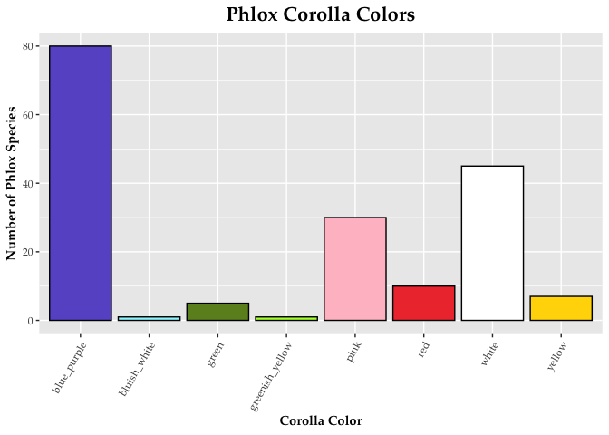

```r
phlox_long %>%
  group_by(color) %>%
  distinct(species) %>%
  ggplot(aes(x=color, fill=color)) +
  geom_bar(color = "black", show.legend = FALSE) + #removed legend because it just repeats what the x-axis says
  scale_fill_manual(values = c("blue_purple" = "slateblue",
                               "bluish_white" = "cadetblue1",
                               "green" = "olivedrab",
                               "greenish_yellow" = "greenyellow",
                               "pink" = "pink",
                               "red" = "brown2",
                               "white" = "white",
                               "yellow" = "gold")) +
  labs(title = "Phlox Corolla Colors", x = "Corolla Color", y = "Number of Phlox Species")+
  theme_gray(base_family = "Palatino")+
  theme(axis.text.x = element_text(angle = 60, hjust = 1),
        axis.title.x = element_text(face = "bold"),
        axis.title.y = element_text(face = "bold"),
        plot.title=element_text(size = rel(1.5), face="bold", hjust=.5))
```

##Pollinator Analysis

```r
phlox_long %>%
  group_by(pollinator) %>%
  distinct(species) %>%
  count(pollinator)
```

```
## # A tibble: 9 x 2
## # Groups:   pollinator [9]
##   pollinator      n
##   <chr>       <int>
## 1 autogamous     50
## 2 bat             4
## 3 bee            38
## 4 bee-fly        27
## 5 beetle          3
## 6 butterfly      16
## 7 fly            10
## 8 hawkmoth       11
## 9 hummingbird    16
```

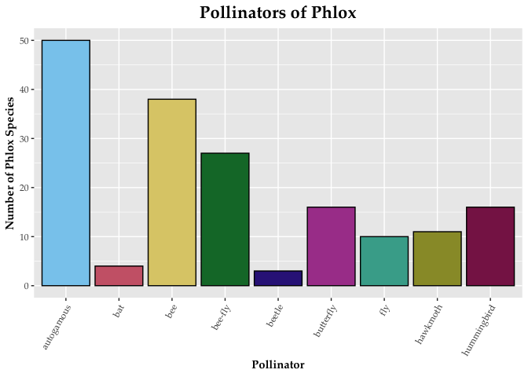

```r
phlox_long %>%
  group_by(pollinator) %>%
  distinct(species) %>%
  ggplot(aes(x= pollinator, fill=pollinator))+
  geom_bar(color = "black", show.legend = FALSE)+
  scale_fill_manual(values = palette) +
  labs(title = "Pollinators of Phlox",
       x = "Pollinator",
       y = "Number of Phlox Species") +
  theme_gray(base_family = "Palatino")+
  theme(axis.text.x = element_text(angle = 60, hjust = 1),
        axis.title.x = element_text(face = "bold"),
        axis.title.y = element_text(face = "bold"),
        plot.title=element_text(size = rel(1.5), face="bold", hjust=.5))
```

```r
#Feel free to play with aesthetics
```

#Looking at Genera With Our Continuous Variables of Mean Corolla Length, Mean Corolla Throat Width, and Mean Corolla Length:Width Ratio Using Box Plots:

##Mean Corolla Length (cm)

```r
min(phlox_long$mean_corolla_length_cm)
```

```
## [1] "0.213"
```

```r
max(phlox_long$mean_corolla_length_cm)
```

```
## [1] "6.639"
```

```r
class(phlox_long$mean_corolla_length_cm)
```

```
## [1] "character"
```

```r
phlox_long$mean_corolla_length_cm <- as.numeric(phlox_long$mean_corolla_length_cm)
is.numeric(phlox_long$mean_corolla_length_cm)
```

```
## [1] TRUE
```

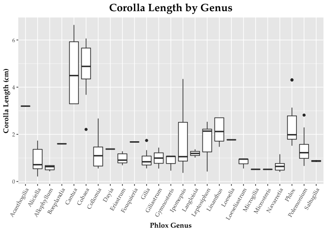

```r
phlox_long %>%
  ggplot(aes(x=genus, y=mean_corolla_length_cm))+
  geom_boxplot()+
  labs(title = "Corolla Length by Genus",
       x = "Phlox Genus",
       y = "Corolla Length (cm)") +
  theme_gray(base_family = "Palatino")+
  theme(axis.text.x = element_text(angle = 60, hjust = 1),
        axis.title.x = element_text(face = "bold"),
        axis.title.y = element_text(face = "bold"),
        plot.title=element_text(size = rel(1.5), face="bold", hjust=.5))
```

##Mean Corolla Throat Width (cm)

```r
class(phlox_long$mean_corolla_width_throat_cm)
```

```
## [1] "character"
```

```r
phlox_long$mean_corolla_width_throat_cm <- as.numeric(phlox_long$mean_corolla_width_throat_cm)
class(phlox_long$mean_corolla_width_throat_cm)
```

```
## [1] "numeric"
```

```r
min(phlox_long$mean_corolla_width_throat_cm)
```

```
## [1] 0.04266667
```

```r
max(phlox_long$mean_corolla_width_throat_cm)
```

```
## [1] 3.531
```

##Mean Corolla Throat Width (cm)

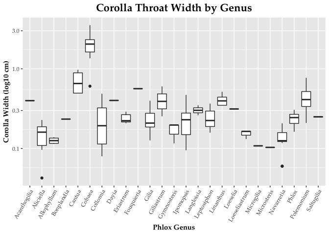

```r
phlox_long %>%
  ggplot(aes(x=genus, y=mean_corolla_width_throat_cm))+
  geom_boxplot()+
  scale_y_log10() +
  labs(title = "Corolla Throat Width by Genus",
       x = "Phlox Genus",
       y = "Corolla Width (log10 cm)") +
  theme_gray(base_family = "Palatino")+
  theme(axis.text.x = element_text(angle = 60, hjust = 1),
        axis.title.x = element_text(face = "bold"),
        axis.title.y = element_text(face = "bold"),
        plot.title=element_text(size = rel(1.5), face="bold", hjust=.5))
```

##Corolla Length:Width Ratio

```r
class(phlox_long$mean_length_width_ratio)
```

```
## [1] "character"
```

```r
phlox_long$mean_length_width_ratio <- as.numeric(phlox_long$mean_length_width_ratio)
class(phlox_long$mean_length_width_ratio)
```

```
## [1] "numeric"
```

```r
min(phlox_long$mean_length_width_ratio)
```

```
## [1] 1.11005
```

```r
max(phlox_long$mean_length_width_ratio)
```

```
## [1] 15.62485
```

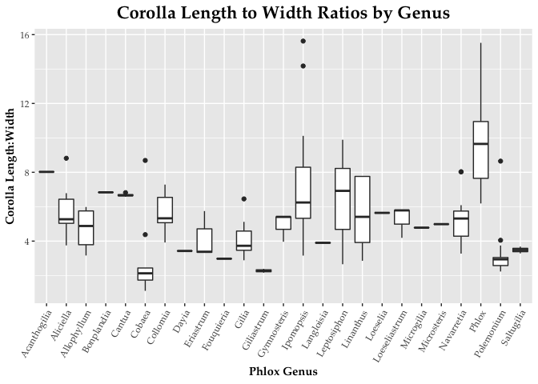

```r
phlox_long %>%
  ggplot(aes(x=genus, y=mean_length_width_ratio))+
  geom_boxplot()+
  labs(title = "Corolla Length to Width Ratios by Genus",
       x = "Phlox Genus",
       y = "Corolla Length:Width") +
  theme_gray(base_family = "Palatino")+
  theme(axis.text.x = element_text(angle = 60, hjust = 1),
        axis.title.x = element_text(face = "bold"),
        axis.title.y = element_text(face = "bold"),
        plot.title=element_text(size = rel(1.5), face="bold", hjust=.5))
```

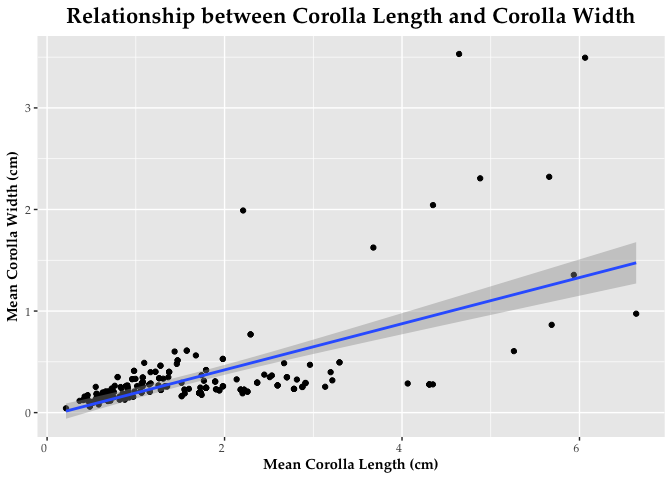

```r
phlox_long %>%
  ggplot(aes(x=mean_corolla_length_cm, y=mean_corolla_width_throat_cm))+
  geom_jitter()+
  geom_smooth(method = "lm")+
  labs(title = "Relationship between Corolla Length and Corolla Width",
       x = "Mean Corolla Length (cm)",
       y = "Mean Corolla Width (cm)") +
  theme_gray(base_family = "Palatino")+
  theme(axis.text.x = element_text(hjust = 1),
        axis.title.x = element_text(face = "bold"),
        axis.title.y = element_text(face = "bold"),
        plot.title=element_text(size = rel(1.5), face="bold", hjust=.5))
```

#Let’s do plots comparing color and pollinators to corolla length:width ratio.

##Color and Corolla Length:Width Ratio

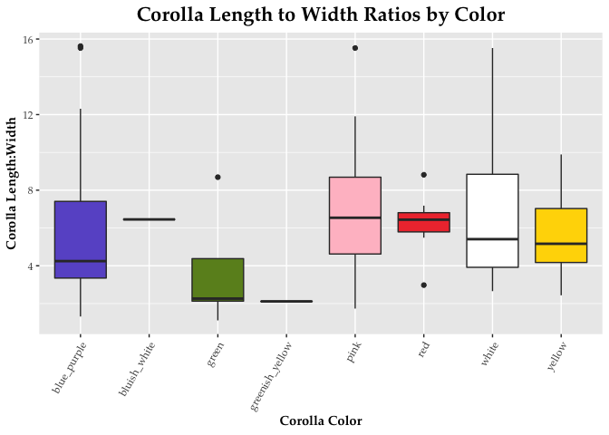

```r
phlox_long %>%
  group_by(color, mean_length_width_ratio) %>%
  distinct(species) %>%
  ggplot(aes(x=color, y=mean_length_width_ratio, fill = color))+
  geom_boxplot(show.legend = FALSE)+
  scale_fill_manual(values = c("blue_purple" = "slateblue",
                               "bluish_white" = "cadetblue1",
                               "green" = "olivedrab",
                               "greenish_yellow" = "greenyellow",
                               "pink" = "pink",
                               "red" = "brown2",
                               "white" = "white",
                               "yellow" = "gold")) +
  labs(title = "Corolla Length to Width Ratios by Color",
       x = "Corolla Color",
       y = "Corolla Length:Width")+
  theme_gray(base_family = "Palatino")+
  theme(axis.text.x = element_text(angle = 60, hjust = 1),
        axis.title.x = element_text(face = "bold"),
        axis.title.y = element_text(face = "bold"),
        plot.title=element_text(size = rel(1.5), face="bold", hjust=.5))
```

##Pollinator and Corolla Length:Width Ratio

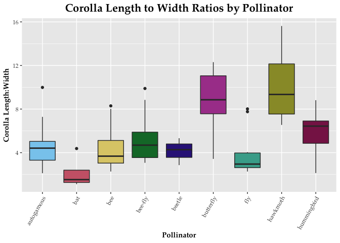

```r
phlox_long %>%
  group_by(pollinator, mean_length_width_ratio) %>%
  distinct(species) %>%
  ggplot(aes(x=pollinator, y=mean_length_width_ratio, fill = pollinator))+
  scale_fill_manual(values = palette) +
  geom_boxplot(show.legend = FALSE)+
  labs(title = "Corolla Length to Width Ratios by Pollinator",
       x = "Pollinator",
       y = "Corolla Length:Width")+
  theme_gray(base_family = "Palatino")+
  theme(axis.text.x = element_text(angle = 60, hjust = 1),
        axis.title.x = element_text(face = "bold"),
        axis.title.y = element_text(face = "bold"),
        plot.title=element_text(size = rel(1.5), face="bold", hjust=.5))
```

#Relative Frequency of Corolla Colors Among Pollinators:

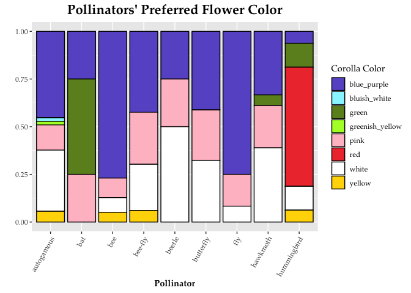

```r
phlox_long %>%
  ggplot(aes(x = pollinator, fill = color)) + geom_bar(position = position_fill(), color = "black") +
  scale_fill_manual(values = c("blue_purple" = "slateblue",
                               "bluish_white" = "cadetblue1",
                               "green" = "olivedrab",
                               "greenish_yellow" = "greenyellow",
                               "pink" = "pink",
                               "red" = "brown2",
                               "white" = "white",
                               "yellow" = "gold")) +
  labs(title = "Pollinators' Preferred Flower Color",
       x = "Pollinator",
       y = "",
       fill = "Corolla Color")+
   theme_gray(base_family = "Palatino")+
  theme(axis.text.x = element_text(angle = 60, hjust = 1),
        axis.title.x = element_text(face = "bold"),
        axis.title.y = element_text(face = "bold"),
        plot.title=element_text(size = rel(1.5), face="bold", hjust=.5))
```

We can start to see some trends in phlox data - we can see that phlox pollinators like hummingbird are overwhelmingly attracted to red flowers. Bees and flies are mostly attracted to the blue_purple range. Bats are mostly attracted to green, but will also pollinate pink or blue_purple.

#Looking at which genera are pollinated by which pollinators:

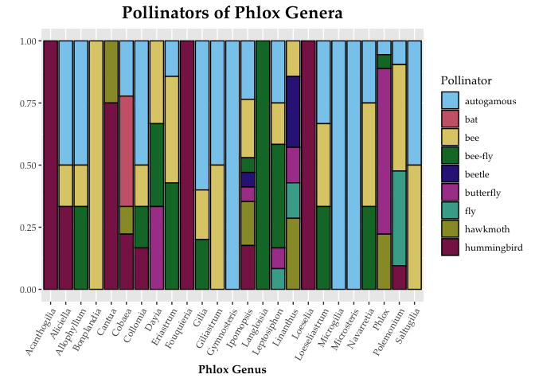

```r
phlox_long %>%
  group_by(genus, pollinator) %>%
  distinct(species) %>%
  ggplot(aes(x = genus, fill = pollinator)) + geom_bar(position = position_fill(), color = "black") +
  scale_fill_manual(values = palette) +
  labs(title = "Pollinators of Phlox Genera",
       x = "Phlox Genus",
       y = "",
       fill = "Pollinator")+
   theme_gray(base_family = "Palatino")+
  theme(axis.text.x = element_text(angle = 60, hjust = 1),
        axis.title.x = element_text(face = "bold"),
        axis.title.y = element_text(face = "bold"),
        plot.title=element_text(size = rel(1.5), face="bold", hjust=.5))
```

#It should be noted, that some genera are only represented by one species so we can’t draw any definite conclusions about some genera only being pollinated by one type of pollinator.

App Looking at Continuous Variables in the Plot:

```r
ui <- fluidPage(
    selectInput("x", "Select X Variable", choices = c("mean_corolla_length_cm", "mean_corolla_width_throat_cm", "mean_length_width_ratio"),
              selected = "mean_corolla_length_cm"),
    selectInput("y", "Select Y Variable", choices = c("mean_corolla_length_cm", "mean_corolla_width_throat_cm", "mean_length_width_ratio"),
              selected = "mean_corolla_width_throat_cm"),
  plotOutput("plot", width = "800px", height = "400px")
)

server <- function(input, output, session) {
  output$plot <- renderPlot({
    ggplot(phlox_long, aes_string(x = input$x, y = input$y, color="genus")) +
      geom_point() +
      theme_classic()+
      theme_light(base_size = 18)
  })

  session$onSessionEnded(stopApp)
}

shinyApp(ui, server)
```

Shiny applications not supported in static R Markdown documents

```r
ui <- fluidPage(
    selectInput("x", "Select Variable", choices = c("genus", "pollinator", "color"),
              selected = "mean_corolla_length_cm"),
    selectInput("y", "Select Y Variable", choices = c("mean_corolla_length_cm", "mean_corolla_width_throat_cm", "mean_length_width_ratio"),
              selected = "mean_corolla_width_throat_cm"),
  plotOutput("plot", width = "800px", height = "400px")
)

server <- function(input, output, session) {
  output$plot <- renderPlot({
    ggplot(phlox_long, aes_string(x = input$x, y = input$y)) +
      scale_fill_manual(values = palette) +
  geom_boxplot(show.legend = FALSE)+
      xlab(paste(input$x,collapse=""))+
      ylab(paste(input$y,collapse=""))+

  labs(title = "Corolla Measurements"#,
       #x = "Genus"#,
       #y = "Corolla Length:Width"
       )+
  theme_gray(base_family = "Palatino")+
  theme(axis.text.x = element_text(angle = 60, hjust = 1),
        axis.title.x = element_text(face = "bold"),
        axis.title.y = element_text(face = "bold"),
        plot.title=element_text(size = rel(1.5), face="bold", hjust=.5))
  })

  session$onSessionEnded(stopApp)
}

shinyApp(ui, server)
```

Shiny applications not supported in static R Markdown documents

choices = c(“Acanthogilia”, “Aliciella”, “Allophyllum”, “Bonplandia”, “Cantua”, “Cobaea”, “Collomia”, “Dayia”, “Eriastrum”, “Fouquieria”, “Gilia”, “Giliastrum”, “Gymnosteris”, “Ipomopsis”, “Langloisia”, “Leptosiphon”, “Linanthus”, “Loeselia”, “Loeseliastrum”, “Microgilia”, “Microsteris”, “Navarretia”, “Phlox”, “Polemonium”, “Saltugilia”)